← Volver a la página principal

# Trabajo Obligatorio 2026

## Modelo Logit aplicado a riesgo de crédito

### Curso

Análisis de Regresión — Posgrado en Finanzas

### Grupo

373027 Ana Clara Viera

242806 Marcela Soba

144172 Gastón Pérez

## Objetivo del trabajo

El objetivo de este trabajo es aplicar un **modelo de regresión logística** a una decisión financiera: evaluar el riesgo crediticio de solicitantes de préstamos.

La pregunta a responder es:

> ¿Qué características de un solicitante de crédito permiten estimar la probabilidad de que el crédito sea malo?

En términos financieros, el modelo busca apoyar una decisión de originación crediticia: aprobar, rechazar o revisar con mayor detalle una solicitud de crédito.

A partir de una base pública de créditos, se solicita construir una notebook en Google Colab replicando los pasos vistos en el curso.

# Descripción del problema financiero

El otorgamiento de crédito implica el riesgo de que el solicitante no cumpla con el pago pactado. Para gestionar ese riesgo, las instituciones financieras necesitan estimar, entes de aprobar una operación qué tan probable es que un crédito termine siendo incumplido. En este trabajo aplicamos un modelo de regresion logística (Logit) sobre una base de solicitantes de crédito, con el fin de estimar esa probabilidad a partir de las características de cada solicitante y, sobre esa base , apoyar la desicion de origen crditicia.

En este contexto se nos plantean las siguientes preguntas:

1. ¿Cuál es la decisión financiera que se quiere apoyar con este modelo?

   El objetivo de este trabajo es aplicar un modelo de regresión logística a una decisión financiera: evaluar el riesgo crediticio de solicitantes de préstamos. En términos financieros, el modelo busca apoyar una decisión de originación crediticia: aprobar, rechazar o revisar con mayor detalle una solicitud de crédito.
2. ¿Por qué un modelo Logit es apropiado para este problema?

   El modelo Logit es apropiado porque la variable que queremos explicar es binaria. Logit modela la probabilidad de que el crédito sea malo mediante la funcion logistica, que mantiene la funcion acotada entre 0 y 1. La probabilidad estimada por este modelo es la base para poder definir luego el unmbral que perimitira servir de apoyo a la decision de aprobar o rechazar una solictud de crédito.
3. ¿Qué representa la variable dependiente?

   La variable dependiente kredit indica si una persona cumplió o no con su contrato de crédito. Es una variable binaria que permite calificar en créditos buenos y créditos malos, en base a si el contrato fue cumplido o no.
4. ¿Qué significa estimar una probabilidad de crédito malo?

   Dadas las variables explicativas que tan probable es que no se cumpla con el pago del credito.
5. ¿Cómo podría usar este modelo una institución financiera?

   Una institución financiera puede hacer uso de esta herramienta definiendo un umbral para estimar qué tan probable es que el cliente cumpla con el pago del crédito o no. Se recaban los datos necesarios del solicitante para tomar una decisión respecto a la otorgación del crédito y minimizar el riesgo de impago.

## Base de datos

Se utilizará la base:

**South German Credit**  
Fuente: UCI Machine Learning Repository  
Tipo de problema: clasificación  
Cantidad de observaciones: 1.000 créditos  
Cantidad de variables explicativas: 20  
Variable objetivo: `kredit`, que indica si el contrato de crédito fue cumplido o no.

La base contiene información sobre solicitantes de crédito, incluyendo duración del préstamo, monto solicitado, historial crediticio, propósito del crédito, empleo, ahorro, edad, situación habitacional, existencia de garantías y otras características relevantes.

La variable dependiente permite clasificar los créditos en dos grupos:

- créditos buenos;
- créditos malos. Link: de Base de Datos: https://archive.ics.uci.edu/dataset/573/south+german+credit+update

## Carga de datos

Se raliza la carga de datos directamente de la base de la UCI

```python
# Librerías
import pandas as pd
import numpy as np
import matplotlib.pyplot as plt
import seaborn as sns
sns.set(style='whitegrid')

# Carga de datos
import urllib.request, zipfile, io

# Modelado y evaluación
from sklearn.model_selection import train_test_split
from sklearn.preprocessing import StandardScaler
from sklearn.metrics import classification_report, confusion_matrix, roc_curve, roc_auc_score
import statsmodels.api as sm
```

```python
# URL oficial del archivo ZIP de UCI para South German Credit
url = "https://archive.ics.uci.edu/ml/machine-learning-databases/00522/SouthGermanCredit.zip"

# Descargar y abrir el ZIP directamente desde Python
with urllib.request.urlopen(url) as response:
    zip_data = response.read()

with zipfile.ZipFile(io.BytesIO(zip_data)) as z:
    print("Archivos dentro del ZIP:", z.namelist())

    # Leer el archivo principal de datos
    with z.open("SouthGermanCredit.asc") as f:
        df = pd.read_csv(f, sep=r"\s+")

# Variable objetivo
# kredit indica el resultado del crédito.
# En esta notebook vamos a modelar la probabilidad de crédito malo.
target = "kredit"

# Variables explicativas y variable dependiente
X = df.drop(columns=[target])
y = df[target]

# Vista inicial de la base
df.head()
```

```
Archivos dentro del ZIP: ['codetable.txt', 'read_SouthGermanCredit.R', 'SouthGermanCredit.asc']
```

|  | laufkont | laufzeit | moral | verw | hoehe | sparkont | beszeit | rate | famges | buerge | ... | verm | alter | weitkred | wohn | bishkred | beruf | pers | telef | gastarb | kredit |
| --- | --- | --- | --- | --- | --- | --- | --- | --- | --- | --- | --- | --- | --- | --- | --- | --- | --- | --- | --- | --- | --- |
| 0 | 1 | 18 | 4 | 2 | 1049 | 1 | 2 | 4 | 2 | 1 | ... | 2 | 21 | 3 | 1 | 1 | 3 | 2 | 1 | 2 | 1 |
| 1 | 1 | 9 | 4 | 0 | 2799 | 1 | 3 | 2 | 3 | 1 | ... | 1 | 36 | 3 | 1 | 2 | 3 | 1 | 1 | 2 | 1 |
| 2 | 2 | 12 | 2 | 9 | 841 | 2 | 4 | 2 | 2 | 1 | ... | 1 | 23 | 3 | 1 | 1 | 2 | 2 | 1 | 2 | 1 |
| 3 | 1 | 12 | 4 | 0 | 2122 | 1 | 3 | 3 | 3 | 1 | ... | 1 | 39 | 3 | 1 | 2 | 2 | 1 | 1 | 1 | 1 |
| 4 | 1 | 12 | 4 | 0 | 2171 | 1 | 3 | 4 | 3 | 1 | ... | 2 | 38 | 1 | 2 | 2 | 2 | 2 | 1 | 1 | 1 |

5 rows × 21 columns

```python
# Revisar nombres de columnas y primeras observaciones
print(df.columns.tolist())
df.head()
```

```
['laufkont', 'laufzeit', 'moral', 'verw', 'hoehe', 'sparkont', 'beszeit', 'rate', 'famges', 'buerge', 'wohnzeit', 'verm', 'alter', 'weitkred', 'wohn', 'bishkred', 'beruf', 'pers', 'telef', 'gastarb', 'kredit']
```

|  | laufkont | laufzeit | moral | verw | hoehe | sparkont | beszeit | rate | famges | buerge | ... | verm | alter | weitkred | wohn | bishkred | beruf | pers | telef | gastarb | kredit |
| --- | --- | --- | --- | --- | --- | --- | --- | --- | --- | --- | --- | --- | --- | --- | --- | --- | --- | --- | --- | --- | --- |
| 0 | 1 | 18 | 4 | 2 | 1049 | 1 | 2 | 4 | 2 | 1 | ... | 2 | 21 | 3 | 1 | 1 | 3 | 2 | 1 | 2 | 1 |
| 1 | 1 | 9 | 4 | 0 | 2799 | 1 | 3 | 2 | 3 | 1 | ... | 1 | 36 | 3 | 1 | 2 | 3 | 1 | 1 | 2 | 1 |
| 2 | 2 | 12 | 2 | 9 | 841 | 2 | 4 | 2 | 2 | 1 | ... | 1 | 23 | 3 | 1 | 1 | 2 | 2 | 1 | 2 | 1 |
| 3 | 1 | 12 | 4 | 0 | 2122 | 1 | 3 | 3 | 3 | 1 | ... | 1 | 39 | 3 | 1 | 2 | 2 | 1 | 1 | 1 | 1 |
| 4 | 1 | 12 | 4 | 0 | 2171 | 1 | 3 | 4 | 3 | 1 | ... | 2 | 38 | 1 | 2 | 2 | 2 | 2 | 1 | 1 | 1 |

5 rows × 21 columns

```python
# Etiquetas oficiales de cada variable categórica (según codetable de UCI)


etiquetas_laufkont = {1: "Sin cuenta corriente", 2: "Saldo < 0 DM",
                      3: "Saldo 0–200 DM", 4: "Saldo ≥ 200 DM / salario"}
etiquetas_moral    = {0: "Atrasos en el pasado", 1: "Cuenta crítica / otros bancos",
                      2: "Sin créditos previos / todos pagados", 3: "Créditos pagados hasta ahora",
                      4: "Todos los créditos en este banco pagados"}
etiquetas_verw     = {0: "Otros", 1: "Auto nuevo", 2: "Auto usado", 3: "Muebles/equipamiento",
                      4: "Radio/TV", 5: "Electrodomésticos", 6: "Reparaciones",
                      7: "Educación", 8: "Vacaciones", 9: "Capacitación", 10: "Negocio"}
etiquetas_sparkont = {1: "Sin ahorro / desconocido", 2: "< 100 DM", 3: "100–500 DM",
                      4: "500–1000 DM", 5: "≥ 1000 DM"}
etiquetas_beszeit  = {1: "Desempleado", 2: "< 1 año", 3: "1–4 años", 4: "4–7 años", 5: "≥ 7 años"}
etiquetas_rate     = {1: "≥ 35% del ingreso", 2: "25–35%", 3: "20–25%", 4: "< 20%"}
etiquetas_famges   = {1: "Hombre: div./separado", 2: "Mujer: no soltera / Hombre: soltero",
                      3: "Hombre: casado/viudo", 4: "Mujer: soltera"}
etiquetas_buerge   = {1: "Ninguno", 2: "Co-solicitante", 3: "Garante"}
etiquetas_wohnzeit = {1: "< 1 año", 2: "1–4 años", 3: "4–7 años", 4: "≥ 7 años"}
etiquetas_verm     = {1: "Sin propiedad / desconocido", 2: "Auto u otro",
                      3: "Ahorro inmob. / seguro de vida", 4: "Inmueble"}
etiquetas_weitkred = {1: "Banco", 2: "Comercios", 3: "Ninguno"}
etiquetas_wohn     = {1: "Gratuita / sin costo", 2: "Alquiler", 3: "Propia"}
etiquetas_bishkred = {1: "1 crédito", 2: "2–3", 3: "4–5", 4: "≥ 6"}
etiquetas_beruf    = {1: "Desempleado/no calif. - no residente", 2: "No calificado - residente",
                      3: "Calificado / oficial", 4: "Gerente / autónomo / muy calificado"}
etiquetas_pers     = {1: "3 o más personas a cargo", 2: "0 a 2 personas a cargo"}
etiquetas_telef    = {1: "No", 2: "Sí"}
etiquetas_gastarb  = {1: "Sí, extranjero", 2: "No extranjero"}

etiquetas_por_var = {"moral": etiquetas_moral, "wohn": etiquetas_wohn}
```

```python
df.info()
df.describe()
```

```
<class 'pandas.core.frame.DataFrame'>
RangeIndex: 1000 entries, 0 to 999
Data columns (total 21 columns):
 #   Column    Non-Null Count  Dtype
---  ------    --------------  -----
 0   laufkont  1000 non-null   int64
 1   laufzeit  1000 non-null   int64
 2   moral     1000 non-null   int64
 3   verw      1000 non-null   int64
 4   hoehe     1000 non-null   int64
 5   sparkont  1000 non-null   int64
 6   beszeit   1000 non-null   int64
 7   rate      1000 non-null   int64
 8   famges    1000 non-null   int64
 9   buerge    1000 non-null   int64
 10  wohnzeit  1000 non-null   int64
 11  verm      1000 non-null   int64
 12  alter     1000 non-null   int64
 13  weitkred  1000 non-null   int64
 14  wohn      1000 non-null   int64
 15  bishkred  1000 non-null   int64
 16  beruf     1000 non-null   int64
 17  pers      1000 non-null   int64
 18  telef     1000 non-null   int64
 19  gastarb   1000 non-null   int64
 20  kredit    1000 non-null   int64
dtypes: int64(21)
memory usage: 164.2 KB
```

|  | laufkont | laufzeit | moral | verw | hoehe | sparkont | beszeit | rate | famges | buerge | ... | verm | alter | weitkred | wohn | bishkred | beruf | pers | telef | gastarb | kredit |
| --- | --- | --- | --- | --- | --- | --- | --- | --- | --- | --- | --- | --- | --- | --- | --- | --- | --- | --- | --- | --- | --- |
| count | 1000.000000 | 1000.000000 | 1000.00000 | 1000.000000 | 1000.00000 | 1000.000000 | 1000.000000 | 1000.000000 | 1000.00000 | 1000.000000 | ... | 1000.000000 | 1000.00000 | 1000.000000 | 1000.000000 | 1000.000000 | 1000.000000 | 1000.000000 | 1000.000000 | 1000.000000 | 1000.000000 |
| mean | 2.577000 | 20.903000 | 2.54500 | 2.828000 | 3271.24800 | 2.105000 | 3.384000 | 2.973000 | 2.68200 | 1.145000 | ... | 2.358000 | 35.54200 | 2.675000 | 1.928000 | 1.407000 | 2.904000 | 1.845000 | 1.404000 | 1.963000 | 0.700000 |
| std | 1.257638 | 12.058814 | 1.08312 | 2.744439 | 2822.75176 | 1.580023 | 1.208306 | 1.118715 | 0.70808 | 0.477706 | ... | 1.050209 | 11.35267 | 0.705601 | 0.530186 | 0.577654 | 0.653614 | 0.362086 | 0.490943 | 0.188856 | 0.458487 |
| min | 1.000000 | 4.000000 | 0.00000 | 0.000000 | 250.00000 | 1.000000 | 1.000000 | 1.000000 | 1.00000 | 1.000000 | ... | 1.000000 | 19.00000 | 1.000000 | 1.000000 | 1.000000 | 1.000000 | 1.000000 | 1.000000 | 1.000000 | 0.000000 |
| 25% | 1.000000 | 12.000000 | 2.00000 | 1.000000 | 1365.50000 | 1.000000 | 3.000000 | 2.000000 | 2.00000 | 1.000000 | ... | 1.000000 | 27.00000 | 3.000000 | 2.000000 | 1.000000 | 3.000000 | 2.000000 | 1.000000 | 2.000000 | 0.000000 |
| 50% | 2.000000 | 18.000000 | 2.00000 | 2.000000 | 2319.50000 | 1.000000 | 3.000000 | 3.000000 | 3.00000 | 1.000000 | ... | 2.000000 | 33.00000 | 3.000000 | 2.000000 | 1.000000 | 3.000000 | 2.000000 | 1.000000 | 2.000000 | 1.000000 |
| 75% | 4.000000 | 24.000000 | 4.00000 | 3.000000 | 3972.25000 | 3.000000 | 5.000000 | 4.000000 | 3.00000 | 1.000000 | ... | 3.000000 | 42.00000 | 3.000000 | 2.000000 | 2.000000 | 3.000000 | 2.000000 | 2.000000 | 2.000000 | 1.000000 |
| max | 4.000000 | 72.000000 | 4.00000 | 10.000000 | 18424.00000 | 5.000000 | 5.000000 | 4.000000 | 4.00000 | 3.000000 | ... | 4.000000 | 75.00000 | 3.000000 | 3.000000 | 4.000000 | 4.000000 | 2.000000 | 2.000000 | 2.000000 | 1.000000 |

8 rows × 21 columns

```python
# Tabla prolija con etiquetas
resumen_kredit = pd.DataFrame({
    "Cantidad": df["kredit"].value_counts(),
    "Porcentaje (%)": (df["kredit"].value_counts(normalize=True) * 100).round(2)
})

resumen_kredit.index = resumen_kredit.index.map({1: "Bueno", 0: "Malo"})
resumen_kredit
```

| kredit | Cantidad | Porcentaje (%) |
| --- | --- | --- |
| Bueno | 700 | 70.0 |
| Malo | 300 | 30.0 |

```python
# Cantidad de valores faltantes por columna
df.isna().sum()

# Total de valores faltantes en toda la base
print("Total de valores faltantes:", df.isna().sum().sum())


faltantes = pd.DataFrame({
    "Valores_faltantes": df.isna().sum(),
    "Porcentaje_faltante": (df.isna().sum() / len(df) * 100).round(2)
})

faltantes
```

```
Total de valores faltantes: 0
```

|  | Valores_faltantes | Porcentaje_faltante |
| --- | --- | --- |
| laufkont | 0 | 0.0 |
| laufzeit | 0 | 0.0 |
| moral | 0 | 0.0 |
| verw | 0 | 0.0 |
| hoehe | 0 | 0.0 |
| sparkont | 0 | 0.0 |
| beszeit | 0 | 0.0 |
| rate | 0 | 0.0 |
| famges | 0 | 0.0 |
| buerge | 0 | 0.0 |
| wohnzeit | 0 | 0.0 |
| verm | 0 | 0.0 |
| alter | 0 | 0.0 |
| weitkred | 0 | 0.0 |
| wohn | 0 | 0.0 |
| bishkred | 0 | 0.0 |
| beruf | 0 | 0.0 |
| pers | 0 | 0.0 |
| telef | 0 | 0.0 |
| gastarb | 0 | 0.0 |
| kredit | 0 | 0.0 |

# Análisis descriptivo de la base

El dataset South German Credit cuenta con mil observaciones, 20 variables explicativas y una variable explicada Kredit. Dentro de las variables, hay tres numéricas y 17 categóricas. La variable explicada Kredit es categórica binaria, en la cual 0 es malo y 1 es bueno. El dataset no tiene valores faltantes. La variable dependiente tiene una distribución de 700 créditos buenos y 300 malos; 70%- 30%. Una de las principales variables numéricas es Laufzeit que refiere a la duración del crédito. Dicha variable presenta un promedio de 20,9 meses y mediana de 18 meses. La duración de los préstamos son de mínimo 4 meses y de máximo 6 años. Hoehe (monto), el promedio de los préstamos son de 3271.25 Marcos Alemanes, la media es de 2319.5, el/los montos mínimos son de 250 y el/los máximos de 18424. Alter (edad), El promedio de la edad de los solicitantes es de 35.54 años, la media es de 33, la edad mínima es de 19 y la máxima de 75.

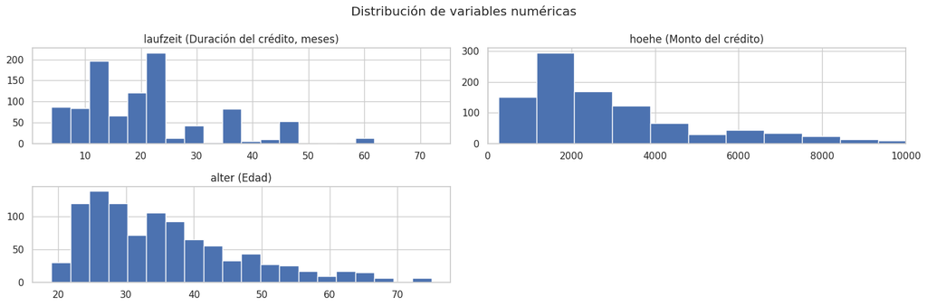

```python
# Variables numéricas de nuestra base
num_cols = ["laufzeit", "hoehe", "alter"]

# Diccionario con el significado en español de cada variable
etiquetas = {
    "laufzeit": "laufzeit (Duración del crédito, meses)",
    "hoehe": "hoehe (Monto del crédito)",
    "alter": "alter (Edad)"
}

# Guardamos los ejes devueltos por hist()
axs = df[num_cols].hist(bins=20, figsize=(15, 5))

# Observación:
# En el histograma de "hoehe" (monto del crédito), el eje X puede quedar muy
# expandido por algunos créditos con montos altos (outliers), lo que aplana
# el gráfico e impide ver bien la forma de la distribución.
# Ajustamos el eje X solo para esa columna, como zoom visual.
for col, ax in zip(num_cols, axs.flatten()):
    ax.set_title(etiquetas[col])  # título con el significado en español
    if col == "hoehe":
        ax.set_xlim(0, 10000)  # ajustar este límite según lo que se quiera visualizar

plt.suptitle("Distribución de variables numéricas")
plt.tight_layout()
plt.show()
```

# Análisis descriptivo de los histogramas

Laufzeit (duración de crédito, meses) - La distribución se encuentra sesgada hacia la derecha con una concentración entre los 12 y 24 meses. - Existen algunos valores extremos hacia la derecha, con créditos cuya duración llega a superar los 60 meses - Desde el punto de vista financiero, esto indica que la muestra está compuesta principalmente por créditos de corto y mediano plazo, mientras que los créditos de muy largo plazo representan una proporción menor. - Tiene sentido que exista una descontinuidad en las duraciones ya que los créditos suelen ser otorgados en plazos múltiplos de 6.

Hoehe (Monto del crédito) - La distribución está fuertemente sesgada a la derecha. Hay muchos créditos de montos bajos o medios y pocos créditos de montos muy elevados. - La mayor concentración se encuentra entre 1.000 y 4.000 marcos alemanes, mientras que la frecuencia disminuye a medida que aumenta el monto de crédito. - Desde el punto de vista financiero, esto indica una cartera heterogénea ya que si bien predominan los créditos de menor monto, hay operaciones más grandes.

Alter (Edad) - La distribución se encuentra segada a la derecha, con pocas observaciones de edades más avanzadas. - La mayor concentración se encuentra en el rango de 25 y 30 años y se puede ver que a mayor edad, menor frecuencia de observaciones. - Desde el punto de vista financiero, la muestra está formada principalmente por clientes adultos jóvenes y de mediana edad, mientras que los clientes de mayor edad representan una proporción considerablemente menor.

Comentario general - En conjunto, los histogramas muestran que las variables numéricas no presentan distribuciones completamente simétricas y tienden a concentrarse en valores relativamente bajos o medios. - Desde el punto de vista financiero, se observa una cartera heterogénea, con predominio de créditos de montos y plazos moderados y una menor cantidad de operaciones de mayor magnitud. - Para el modelo Logit esto no impide estimar, pero es importante tenerlo presente al interpretar coeficientes, evaluar outliers y considerar escalamiento o transformaciones de variables.

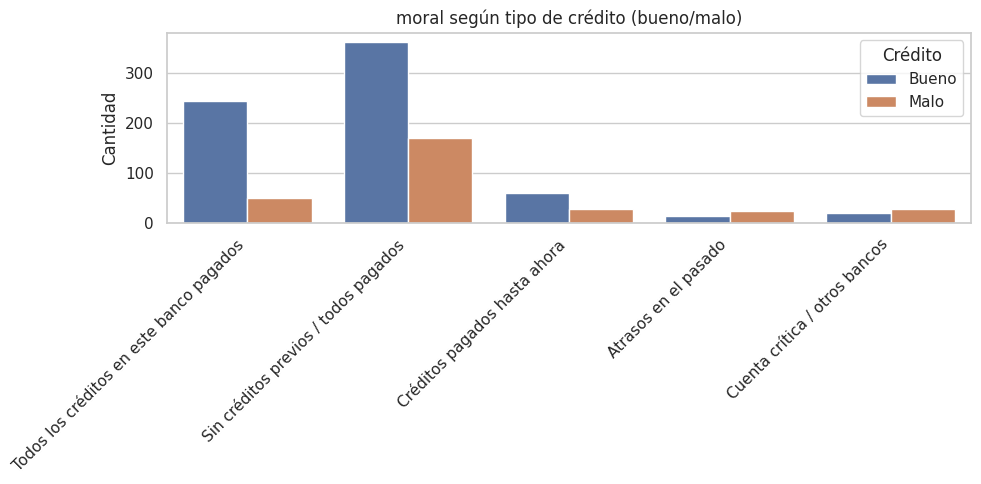

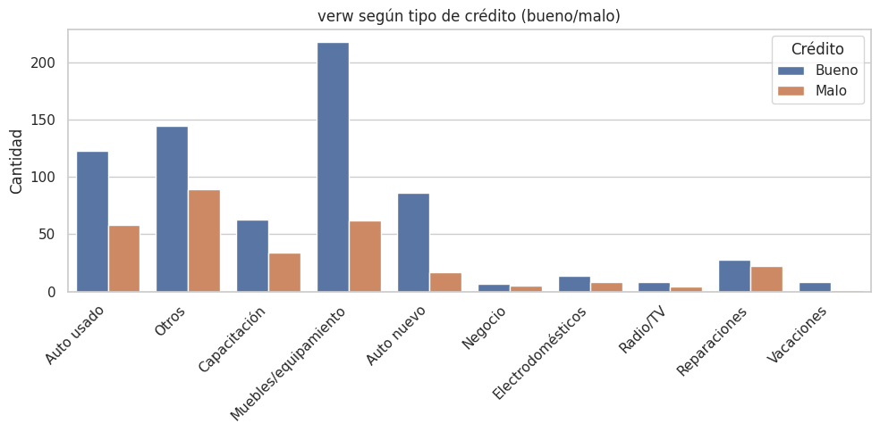

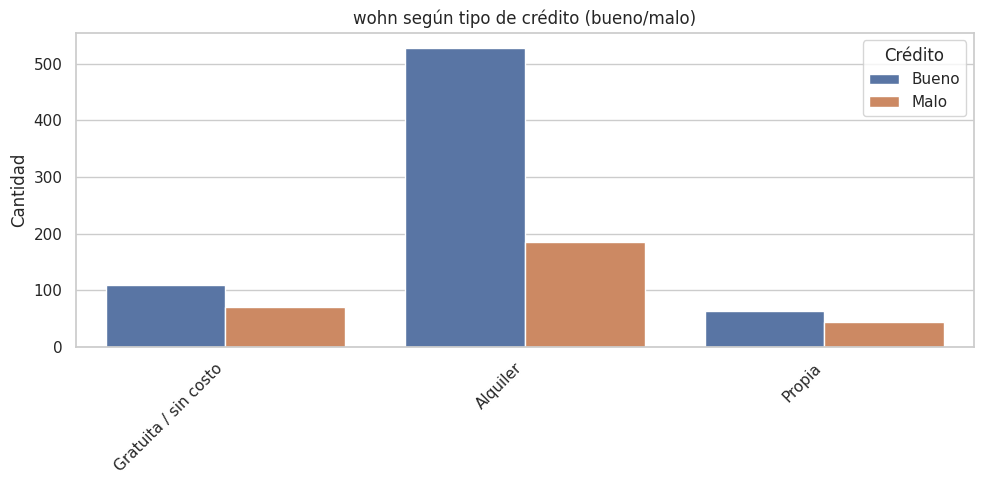

```python
# Etiquetamos la variable objetivo para que se lea claro en la leyenda
df['kredit_label'] = df['kredit'].map({1: 'Bueno', 0: 'Malo'})

df['moral_label'] = df['moral'].map(etiquetas_moral)
df['verw_label'] = df['verw'].map(etiquetas_verw)
df['wohn_label'] = df['wohn'].map(etiquetas_wohn)

cat_vars = ['moral_label', 'verw_label', 'wohn_label']

for var in cat_vars:
    plt.figure(figsize=(10, 5))
    sns.countplot(x=var, data=df, hue='kredit_label')
    plt.title(f'{var.replace("_label", "")} según tipo de crédito (bueno/malo)')
    plt.ylabel('Cantidad')
    plt.xlabel('')
    plt.xticks(rotation=45, ha='right')
    plt.yscale('linear')
    plt.legend(title='Crédito')
    plt.tight_layout()
    plt.show()
```

# Análisis descriptivo gráficos de barra

Moral según tipo de crédito (bueno/malo)

Verw según tipo de crédito (bueno/malo)

- La categoría más numerosa corresponde a “Muebles/equipamiento”, seguida por “Otros” y “Auto usado”.
- En todas las categorías hay más créditos buenos que malos. La mayor proporción de créditos malos se encuentra en la categoría "Reparaciones"
- Esto podría implicar que quienes solicitan crédito para destinar en reparaciones representan más riesgo de crédito, mientras que quienes lo solicitan para vacaciones representan casi escaso riesgo. Igualmente en esta última categoría son muy pocas observaciones por lo que puede no ser representativa.

Wohn según tipo de crédito (bueno/malo)

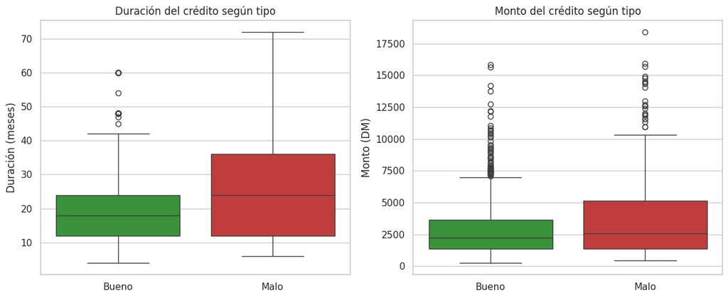

```python
fig, axes = plt.subplots(1, 2, figsize=(12, 5))

sns.boxplot(x='kredit_label', y='laufzeit', data=df, ax=axes[0],
            palette={'Bueno': '#2ca02c', 'Malo': '#d62728'})
axes[0].set_title('Duración del crédito según tipo')
axes[0].set_xlabel('')
axes[0].set_ylabel('Duración (meses)')

sns.boxplot(x='kredit_label', y='hoehe', data=df, ax=axes[1],
            palette={'Bueno': '#2ca02c', 'Malo': '#d62728'})
axes[1].set_title('Monto del crédito según tipo')
axes[1].set_xlabel('')
axes[1].set_ylabel('Monto (DM)')



plt.tight_layout()
plt.show()
import warnings
warnings.filterwarnings('ignore')
```

# Análisis descrptivo Diagramas de caja

Duración del crédito

- La mediana de la duración de los créditos malos es mayor que los buenos.
- La duración de los créditos malos tiene observaciones hasta los 72 meses mientras que los créditos buenos se concentran entre los 12 y 24 meses con algunas observaciones atípicas.
- Esto puede implicar que los créditos de mayor plazo corren mayor riesgo de ser créditos malos.

Monto del crédito

- La mediana del monto de los créditos malos es apenas superior a la de los créditos buenos.
- Los créditos malos en este gráfico vuelven a tener mayor dispersión que los buenos en monto y nuestran valores más altos.
- Tanto para los créditos buenos como para los malos hay muchos valores atípicos. Este diagrama tiene relación con el histograma hoehe.
- Este diagrama da indicios de que a mayor monto de crédito, mayor riesgo de crédito malo.

```
               laufzeit        hoehe
kredit_label
Bueno         19.207143  2985.442857
Malo          24.860000  3938.126667
```

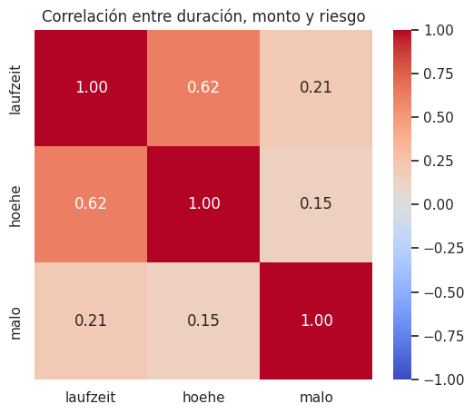

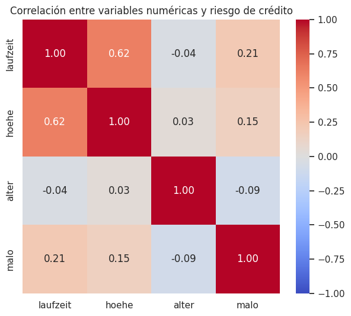

```python
# Promedio de duración y monto, separado por tipo de crédito
resumen_duracion_monto = df.groupby('kredit_label')[['laufzeit', 'hoehe']].mean()
resumen_duracion_monto
print(resumen_duracion_monto)

#Creamos la variable de riesgo: 1 = malo, 0 = bueno
df['malo'] = (df['kredit'] == 0).astype(int)

# Primer heatmap: duración, monto y riesgo
num_cols_riesgo = ["laufzeit", "hoehe", "malo"]
plt.figure(figsize=(6, 5))
sns.heatmap(df[num_cols_riesgo].corr(), annot=True, fmt='.2f', cmap='coolwarm', vmin=-1, vmax=1)
plt.title('Correlación entre duración, monto y riesgo')
plt.show()



# Segundo heatmap: agrega la edad
num_cols_completo = ["laufzeit", "hoehe", "alter", "malo"]
plt.figure(figsize=(7, 6))
sns.heatmap(df[num_cols_completo].corr(), annot=True, fmt='.2f', cmap='coolwarm', vmin=-1, vmax=1)
plt.title('Correlación entre variables numéricas y riesgo de crédito')
plt.show()
```

# Análisis descrptivo Matriz de Correlación

Diagrama de correlación entre duración, monto y riesgo

- El diagrama ilustra una correlación positiva de 0,62 entre las variables duración y monto, indicando que si el monto del crédito crece también lo hace la duración.
- Todas las correlaciones son positivas. Sin embargo, la correlación entre "malo" y "hoehe" y "malo" y "laufzeit" son más débiles.

Diagrama de correlación entre variables numéricas y riesgo de crédito

- Este diagrama agrega la variable "alter" al análisis realizado en el diagrama anterior. "alter" tiene una correlación negativa muy débil con la variable de riesgo de crédito y una correlación positiva muy débil por no decir nula con la variable "hoehe".
- Ninguna correlación es demasiado alta como para ser preocupante. La correlación entre las variables de monto y duración no es tan elevada como para sugerir un problema de multicolinealidad. En ese caso se podría estudiar mediante el VIF.

# Clasificación de variables numéricas y categóricas

```python
# Clasificación manual de variables (numéricas vs categóricas)

variables_numericas = ["laufzeit", "hoehe", "alter"]  # duración, monto, edad

variables_categoricas = [
    "laufkont", "moral", "verw", "sparkont", "beszeit", "rate",
    "famges", "buerge", "wohnzeit", "verm", "weitkred", "wohn",
    "bishkred", "beruf", "pers", "telef", "gastarb"
]

print("Variables numéricas:", len(variables_numericas))
print("Variables categóricas:", len(variables_categoricas))
print("Variable objetivo (kredit): categórica binaria (0 = malo, 1 = bueno)")
```

```
Variables numéricas: 3
Variables categóricas: 17
Variable objetivo (kredit): categórica binaria (0 = malo, 1 = bueno)
```

```python
#descripcion de las variables
diccionario_variables = pd.DataFrame([
    ["laufkont",  "Estado de la cuenta corriente del deudor",           "Categórica"],
    ["laufzeit",  "Duración del crédito (meses)",                       "Numérica"],
    ["moral",     "Historial de cumplimiento de créditos previos",      "Categórica"],
    ["verw",      "Propósito del crédito",                              "Categórica"],
    ["hoehe",     "Monto del crédito (DM)",                             "Numérica"],
    ["sparkont",  "Ahorros del deudor",                                 "Categórica"],
    ["beszeit",   "Antigüedad laboral con el empleador actual",         "Categórica ordinal"],
    ["rate",      "Cuota como % del ingreso disponible",                "Categórica ordinal"],
    ["famges",    "Estado civil y sexo (combinado)",                    "Categórica"],
    ["buerge",    "Existencia de otro deudor o garante",                "Categórica"],
    ["wohnzeit",  "Años viviendo en la residencia actual",              "Categórica ordinal"],
    ["verm",      "Propiedad más valiosa del deudor",                   "Categórica ordinal"],
    ["alter",     "Edad (años)",                                        "Numérica"],
    ["weitkred",  "Otros planes de crédito (fuera del banco)",          "Categórica"],
    ["wohn",      "Tipo de vivienda",                                   "Categórica"],
    ["bishkred",  "N° de créditos que tiene/tuvo en este banco",        "Categórica ordinal"],
    ["beruf",     "Calidad del empleo",                                 "Categórica ordinal"],
    ["pers",      "Personas a cargo del deudor",                        "Categórica"],
    ["telef",     "Tiene línea de teléfono a su nombre",                "Categórica binaria"],
    ["gastarb",   "Es trabajador extranjero",                           "Categórica binaria"],
    ["kredit",    "Variable objetivo: crédito cumplido (1) o no (0)",   "Categórica binaria (target)"],
], columns=["Variable", "Descripción", "Tipo"])

diccionario_variables
```

|  | Variable | Descripción | Tipo |
| --- | --- | --- | --- |
| 0 | laufkont | Estado de la cuenta corriente del deudor | Categórica |
| 1 | laufzeit | Duración del crédito (meses) | Numérica |
| 2 | moral | Historial de cumplimiento de créditos previos | Categórica |
| 3 | verw | Propósito del crédito | Categórica |
| 4 | hoehe | Monto del crédito (DM) | Numérica |
| 5 | sparkont | Ahorros del deudor | Categórica |
| 6 | beszeit | Antigüedad laboral con el empleador actual | Categórica ordinal |
| 7 | rate | Cuota como % del ingreso disponible | Categórica ordinal |
| 8 | famges | Estado civil y sexo (combinado) | Categórica |
| 9 | buerge | Existencia de otro deudor o garante | Categórica |
| 10 | wohnzeit | Años viviendo en la residencia actual | Categórica ordinal |
| 11 | verm | Propiedad más valiosa del deudor | Categórica ordinal |
| 12 | alter | Edad (años) | Numérica |
| 13 | weitkred | Otros planes de crédito (fuera del banco) | Categórica |
| 14 | wohn | Tipo de vivienda | Categórica |
| 15 | bishkred | N° de créditos que tiene/tuvo en este banco | Categórica ordinal |
| 16 | beruf | Calidad del empleo | Categórica ordinal |
| 17 | pers | Personas a cargo del deudor | Categórica |
| 18 | telef | Tiene línea de teléfono a su nombre | Categórica binaria |
| 19 | gastarb | Es trabajador extranjero | Categórica binaria |
| 20 | kredit | Variable objetivo: crédito cumplido (1) o no (0) | Categórica binaria (target) |

Categórica (nominal): son categorías donde no hay ningún orden lógico entre ellas — son simplemente "distintas", ninguna es "más" o "menos" que otra. Ejemplo de tu base: verw (propósito del crédito) puede ser "auto nuevo", "muebles", "educación", "vacaciones"... No tiene sentido decir que "auto nuevo" es mayor o menor que "vacaciones", son simplemente opciones diferentes. Otro ejemplo de la vida diaria: el color de un auto (rojo, azul, verde) — ningún color es "más" que otro.

Categórica ordinal: son categorías que sí tienen un orden natural, de menor a mayor (o al revés), aunque la distancia entre una categoría y otra no sea necesariamente igual. Ejemplo de tu base: beszeit (antigüedad laboral) va de "desempleado" → "menos de 1 año" → "1 a 4 años" → "4 a 7 años" → "más de 7 años". Ahí sí hay un orden claro: cada categoría representa más antigüedad que la anterior. Otro ejemplo cotidiano: el talle de una remera (S, M, L, XL) — hay un orden, pero no sabés si la diferencia entre S y M es "igual" que entre L y XL.

Categórica binaria: es un caso particular donde la variable solo tiene dos categorías posibles, ni más ni menos. Puede o no tener orden, pero lo que la define es que solo hay dos opciones. Ejemplo de tu base: telef (tiene teléfono: sí/no), gastarb (trabajador extranjero: sí/no), y la propia variable objetivo kredit (crédito bueno/malo). Es como una moneda: cara o cruz, no hay una tercera opción.

# Preparación de datos

```python
# Copia del dataframe original
df_model = df.copy()

# Sacamos las columnas auxiliares creadas antes para los gráficos:
# kredit_label y es_malo son el target disfrazado; moral_label, verw_label y
# wohn_label son duplicados con etiquetas de columnas que ya están en la base.
columnas_auxiliares = ["kredit_label", "es_malo","malo", "moral_label", "verw_label", "wohn_label"]
df_model = df_model.drop(columns=[c for c in columnas_auxiliares if c in df_model.columns])

#  Variables verdaderamente numéricas
variables_numericas = ["laufzeit", "hoehe", "alter"]

# Todas las demás variables explicativas son categóricas

# optamos por tratarlas todas como categóricas para no imponer un orden numérico que podría no reflejar el riesgo.

variables_categoricas = [col for col in df_model.columns
                          if col not in variables_numericas + ["kredit"]]

# Marcar explícitamente esas columnas como categóricas
for col in variables_categoricas:
    df_model[col] = df_model[col].astype("category")

# Definir la categoría poositiva del model (1 = crédito malo)
df_model["target"] = (df_model["kredit"] == 0).astype(int)
df_model = df_model.drop(columns=["kredit"])

# Crear variables dummy para las categóricas
# Por defecto el drop_first = true saca la primera variable de cada categoria
df_model = pd.get_dummies(df_model, columns=variables_categoricas, drop_first=True)

# Separar X e y
X = df_model.drop(columns=["target"])
y = df_model["target"]
```

Recodificación de la variable objetivo. En la base original, la variable kredit está codificada con 1 para los créditos buenos y 0 para los malos. El modelo Logit estima la probabilidad de ocurrencia de la categoría codificada como 1 (la "categoría positiva"). Por lo tanto, si utilizáramos la variable tal como viene, el modelo estimaría la probabilidad de que un crédito sea bueno, que es lo contrario de lo que buscamos.

Dado que el objetivo es evaluar el riesgo crediticio, la probabilidad de que un crédito resulte malo, recodificamos la variable en target, asignando 1 al crédito malo y 0 al bueno (target = (kredit == 0)). Con esta transformación, la probabilidad estimada por el modelo se interpreta directamente como la probabilidad de incumplimiento, y los signos de los coeficientes quedan alineados con el riesgo: un coeficiente positivo indica que la variable aumenta la probabilidad de crédito malo, y uno negativo, que la reduce.

Esta recodificación es importante porque, de no realizarse, el modelo se estimaría igual y sin arrojar ningún error, pero toda la interpretación de los resultados quedaría invertida.

# Variables dummy y categorías base

Al aplicar `pd.get_dummies(df_model, columns=variables_categoricas, drop_first=True)`, cada variable categórica pierde su primera categoría (la de código más bajo), que queda como **categoría base** de referencia. Los coeficientes del modelo se interpretan siempre en comparación con esa categoría base. Se decidió mantener la primer categoría de cada variable a modo de simplificar.

| Variable | Dummies incluidas en el modelo | Categoría base omitida |
| --- | --- | --- |
| `laufkont` (estado cuenta corriente) | `laufkont_2`, `laufkont_3`, `laufkont_4` | Sin cuenta corriente |
| `moral` (historial crediticio) | `moral_1` a `moral_4` | Categoría 0 (atrasos previos) |
| `verw` (propósito del crédito) | `verw_1` a `verw_10` | Categoría 0 ("otros") |
| `sparkont` (ahorros) | `sparkont_2` a `sparkont_5` | Sin cuenta de ahorro / desconocido |
| `beszeit` (antigüedad laboral) | `beszeit_2` a `beszeit_5` | Desempleado |
| `rate` (cuota como % del ingreso) | `rate_2` a `rate_4` | Categoría 1 |
| `famges` (estado civil/sexo) | `famges_2` a `famges_4` | Categoría 1 |
| `buerge` (garante/codeudor) | `buerge_2`, `buerge_3` | Sin garante |
| `wohnzeit` (años en residencia actual) | `wohnzeit_2` a `wohnzeit_4` | Menos de 1 año |
| `verm` (patrimonio/propiedad) | `verm_2` a `verm_4` | Sin propiedad / desconocido |
| `weitkred` (otros créditos vigentes) | `weitkred_2`, `weitkred_3` | Categoría 1 |
| `wohn` (vivienda) | `wohn_2`, `wohn_3` | Categoría 1 |
| `bishkred` (créditos previos en el banco) | `bishkred_2` a `bishkred_4` | 1 crédito previo |
| `beruf` (empleo) | `beruf_2` a `beruf_4` | Categoría 1 |
| `pers` (personas a cargo) | `pers_2` | Categoría 1 |
| `telef` (teléfono) | `telef_2` | No tiene teléfono |
| `gastarb` (trabajador extranjero) | `gastarb_2` | Sí, es trabajador extranjero |

```python
# Diccionario de etiquetas por variable
# Juntamos todas las etiquetas en un solo diccionario, por variable
etiquetas_por_var = {
    "laufkont": etiquetas_laufkont, "moral": etiquetas_moral, "verw": etiquetas_verw,
    "sparkont": etiquetas_sparkont, "beszeit": etiquetas_beszeit, "rate": etiquetas_rate,
    "famges": etiquetas_famges, "buerge": etiquetas_buerge, "wohnzeit": etiquetas_wohnzeit,
    "verm": etiquetas_verm, "weitkred": etiquetas_weitkred, "wohn": etiquetas_wohn,
    "bishkred": etiquetas_bishkred, "beruf": etiquetas_beruf, "pers": etiquetas_pers,
    "telef": etiquetas_telef, "gastarb": etiquetas_gastarb,
}

filas = []
for col in variables_categoricas:
    codigo_base = sorted(df[col].unique())[0]
    etiqueta_base = etiquetas_por_var.get(col, {}).get(codigo_base, codigo_base)
    filas.append((col, codigo_base, etiqueta_base))

tabla_bases = pd.DataFrame(filas, columns=["Variable", "Código base", "Significado de la base"])
tabla_bases
```

|  | Variable | Código base | Significado de la base |
| --- | --- | --- | --- |
| 0 | laufkont | 1 | Sin cuenta corriente |
| 1 | moral | 0 | Atrasos en el pasado |
| 2 | verw | 0 | Otros |
| 3 | sparkont | 1 | Sin ahorro / desconocido |
| 4 | beszeit | 1 | Desempleado |
| 5 | rate | 1 | ≥ 35% del ingreso |
| 6 | famges | 1 | Hombre: div./separado |
| 7 | buerge | 1 | Ninguno |
| 8 | wohnzeit | 1 | < 1 año |
| 9 | verm | 1 | Sin propiedad / desconocido |
| 10 | weitkred | 1 | Banco |
| 11 | wohn | 1 | Gratuita / sin costo |
| 12 | bishkred | 1 | 1 crédito |
| 13 | beruf | 1 | Desempleado/no calif. - no residente |
| 14 | pers | 1 | 3 o más personas a cargo |
| 15 | telef | 1 | No |
| 16 | gastarb | 1 | Sí, extranjero |

# Estimación del modelo Logit

```python
# Modelo completo con todas las observaciones y todas las variables

scaler_full = StandardScaler()
X_scaled_full = X.copy()
X_scaled_full[variables_numericas] = scaler_full.fit_transform(X[variables_numericas])
X_scaled_full = sm.add_constant(X_scaled_full)
X_scaled_full = X_scaled_full.astype(float)

y_full = y.astype(float)

modelo_completo = sm.Logit(y_full, X_scaled_full).fit()
print(modelo_completo.summary())
```

```
Optimization terminated successfully.
         Current function value: 0.446479
         Iterations 7
                           Logit Regression Results
==============================================================================
Dep. Variable:                 target   No. Observations:                 1000
Model:                          Logit   Df Residuals:                      945
Method:                           MLE   Df Model:                           54
Date:                Fri, 28 Aug 2026   Pseudo R-squ.:                  0.2691
Time:                        22:23:04   Log-Likelihood:                -446.48
converged:                       True   LL-Null:                       -610.86
Covariance Type:            nonrobust   LLR p-value:                 4.890e-41
==============================================================================
                 coef    std err          z      P>|z|      [0.025      0.975]
------------------------------------------------------------------------------
const          0.0485      1.100      0.044      0.965      -2.108       2.205
laufzeit       0.3414      0.113      3.012      0.003       0.119       0.564
hoehe          0.3384      0.127      2.672      0.008       0.090       0.587
alter         -0.1428      0.105     -1.357      0.175      -0.349       0.063
laufkont_2    -0.3783      0.219     -1.728      0.084      -0.807       0.051
laufkont_3    -0.9630      0.370     -2.600      0.009      -1.689      -0.237
laufkont_4    -1.7519      0.234     -7.491      0.000      -2.210      -1.294
moral_1        0.1852      0.569      0.326      0.745      -0.929       1.300
moral_2       -0.6038      0.443     -1.362      0.173      -1.473       0.265
moral_3       -0.9735      0.479     -2.033      0.042      -1.912      -0.035
moral_4       -1.5122      0.446     -3.389      0.001      -2.387      -0.638
verw_1        -1.6291      0.377     -4.322      0.000      -2.368      -0.890
verw_2        -0.7287      0.263     -2.772      0.006      -1.244      -0.213
verw_3        -0.8507      0.248     -3.427      0.001      -1.337      -0.364
verw_4        -0.4994      0.767     -0.651      0.515      -2.002       1.003
verw_5        -0.1943      0.554     -0.351      0.726      -1.280       0.892
verw_6         0.1163      0.396      0.293      0.769      -0.660       0.893
verw_8        -1.9154      1.170     -1.637      0.102      -4.209       0.378
verw_9        -0.6524      0.336     -1.940      0.052      -1.311       0.007
verw_10       -1.3873      0.779     -1.780      0.075      -2.915       0.140
sparkont_2    -0.3730      0.291     -1.280      0.201      -0.944       0.198
sparkont_3    -0.3580      0.401     -0.894      0.372      -1.143       0.427
sparkont_4    -1.4216      0.534     -2.663      0.008      -2.468      -0.375
sparkont_5    -0.9648      0.265     -3.643      0.000      -1.484      -0.446
beszeit_2      0.0104      0.439      0.024      0.981      -0.850       0.871
```

[output cut: 16 more lines]

```
verm_4         0.7113      0.424      1.678      0.093      -0.119       1.542
weitkred_2     0.0351      0.426      0.082      0.934      -0.801       0.871
weitkred_3    -0.4040      0.247     -1.633      0.102      -0.889       0.081
wohn_2        -0.4742      0.236     -2.007      0.045      -0.937      -0.011
wohn_3        -0.6108      0.480     -1.274      0.203      -1.551       0.329
bishkred_2     0.3896      0.247      1.580      0.114      -0.094       0.873
bishkred_3     0.3155      0.600      0.526      0.599      -0.860       1.490
bishkred_4     0.3676      1.075      0.342      0.732      -1.739       2.474
beruf_2        0.5306      0.679      0.781      0.435      -0.801       1.862
beruf_3        0.5397      0.655      0.824      0.410      -0.745       1.824
beruf_4        0.4318      0.666      0.648      0.517      -0.874       1.737
pers_2        -0.2607      0.251     -1.038      0.299      -0.753       0.232
telef_2       -0.2677      0.203     -1.322      0.186      -0.665       0.129
gastarb_2      1.3989      0.622      2.248      0.025       0.179       2.619
==============================================================================
```

```python
# --- Selección automática de variables: Backward Elimination ---
# Arranca con todas las variables y elimina, una por vez, la de mayor p-valor
# mientras ese p-valor supere el umbral (0.05). Devuelve el modelo final y su X.

def backward_elimination(X, y, threshold=0.05):
    X = X.copy()
    while True:
        modelo = sm.Logit(y, X).fit(disp=0)          # disp=0 evita imprimir en cada vuelta
        pvals = modelo.pvalues.drop("const", errors="ignore")  # no evaluamos la constante
        max_p = pvals.max()                          # el p-valor más alto que quedó
        if max_p > threshold:
            quitar = pvals.idxmax()                  # nombre de esa variable
            X = X.drop(columns=[quitar])             # la sacamos
        else:
            break                                    # si todas son significativas, paramos
    return modelo, X
```

```python
# Aplicamos la selección sobre el modelo completo (toda la base)

modelo_reducido, X_reducido = backward_elimination(X_scaled_full, y_full)

print("Variables iniciales:", X_scaled_full.shape[1] - 1)      # -1 por la constante
print("Variables finales:  ", X_reducido.shape[1] - 1)
print(modelo_reducido.summary())
```

```
Variables iniciales: 54
Variables finales:   19
                           Logit Regression Results
==============================================================================
Dep. Variable:                 target   No. Observations:                 1000
Model:                          Logit   Df Residuals:                      980
Method:                           MLE   Df Model:                           19
Date:                Fri, 28 Aug 2026   Pseudo R-squ.:                  0.2353
Time:                        22:23:07   Log-Likelihood:                -467.10
converged:                       True   LL-Null:                       -610.86
Covariance Type:            nonrobust   LLR p-value:                 7.161e-50
==============================================================================
                 coef    std err          z      P>|z|      [0.025      0.975]
------------------------------------------------------------------------------
const          0.2552      0.686      0.372      0.710      -1.089       1.599
laufzeit       0.3473      0.104      3.342      0.001       0.144       0.551
hoehe          0.2690      0.111      2.419      0.016       0.051       0.487
laufkont_2    -0.4732      0.200     -2.367      0.018      -0.865      -0.081
laufkont_3    -1.0916      0.354     -3.083      0.002      -1.786      -0.398
laufkont_4    -1.8304      0.219     -8.355      0.000      -2.260      -1.401
moral_2       -0.8246      0.277     -2.974      0.003      -1.368      -0.281
moral_3       -0.9793      0.367     -2.671      0.008      -1.698      -0.261
moral_4       -1.4200      0.308     -4.609      0.000      -2.024      -0.816
verw_1        -1.3041      0.335     -3.889      0.000      -1.961      -0.647
verw_3        -0.4914      0.197     -2.495      0.013      -0.877      -0.105
sparkont_4    -1.2069      0.498     -2.424      0.015      -2.183      -0.231
sparkont_5    -0.8812      0.246     -3.581      0.000      -1.364      -0.399
beszeit_4     -0.5328      0.234     -2.279      0.023      -0.991      -0.075
rate_4         0.5897      0.178      3.314      0.001       0.241       0.938
famges_3      -0.4588      0.170     -2.707      0.007      -0.791      -0.127
buerge_3      -0.9612      0.414     -2.324      0.020      -1.772      -0.151
wohnzeit_2     0.4536      0.182      2.498      0.012       0.098       0.809
wohn_2        -0.4793      0.181     -2.643      0.008      -0.835      -0.124
gastarb_2      1.2592      0.627      2.007      0.045       0.029       2.489
==============================================================================
```

```python
# Comparación de ambos modelos por AIC (más bajo = mejor equilibrio ajuste/complejidad)

print("Modelo completo  -> AIC:", round(modelo_completo.aic, 1),
      "| Pseudo R2:", round(modelo_completo.prsquared, 3))
print("Modelo reducido  -> AIC:", round(modelo_reducido.aic, 1),
      "| Pseudo R2:", round(modelo_reducido.prsquared, 3))
```

```
Modelo completo  -> AIC: 1003.0 | Pseudo R2: 0.269
Modelo reducido  -> AIC: 974.2 | Pseudo R2: 0.235
```

Selección automática de variables (Backward Elimination). Partiendo del modelo con todas las variables, se eliminan iterativamente aquellas con p-valor mayor a 0,05, quedándonos solo con las estadísticamente significativas. El modelo pasó de 54 a 19 variables, reduciendo el AIC de 1003 a 974 (mejor equilibrio entre ajuste y complejidad) sin una pérdida relevante de capacidad explicativa. El modelo reducido es más parsimonioso, más estable y más fácil de interpretar, y es el que usaremos en la interpretación financiera.

# Interpretación financiera de los resultados

Las variables que aumentan la probabilidad de crédito malo son aquellas de coeficiente positivo y significativo:

Duración (laufzeit, +0,35) y monto (hoehe, +0,27): a mayor plazo y monto, mayor el riesgo de credito.

Cuota baja como % del ingreso (rate_4, +0,59), residencia de 1–4 años (wohnzeit_2, +0,45) y no ser trabajador extranjero (gastarb_2, +1,26): aumentan el riesgo respecto de su base, aunque su interpretación no es tan directa.

Las variables qure reducen esa probabilidad de que el credito sea malo son aquellas de coeficiente negativo y significativo, que son la mayoría:

Estado de la cuenta corriente (laufkont): cuanto mejor la cuenta, menor el riesgo. La categoría "≥200 DM" (laufkont_4, −1,83) es la que más lo baja de todo el modelo. Historial crediticio (moral): haber pagado créditos anteriores en regla reduce fuertemente el riesgo (moral_4, −1,42). Ahorros (sparkont): más ahorros, menos riesgo (sparkont_4, −1,21). Propósito (verw): pedir el crédito para auto nuevo (−1,30) o muebles (−0,49) es menos riesgoso que la categoría "otros". Tener un garante (buerge_3, −0,96), empleo estable de 4–7 años (beszeit_4, −0,53), vivienda en alquiler vs. gratuita (wohn_2, −0,48) y estar casado/viudo (famges_3, −0,46).

En su mayoría los signos del coeficiente de las variables tienen sentido financiero, por ejemplo: mejor cuenta, mejor historial, más ahorros, tener garante y empleo estable reducen el riesgo; más monto y más plazo lo aumentan. Todo coherente con el sentido común crediticio.

Pero hay tres resultados contraintuitivos que conviene mencionar que el modelo reducido dejó porque son significativos:

**rate_4** (cuota < 20% del ingreso) aumenta el riesgo. Uno esperaría lo contrario. En los datos, efectivamente los de cuota más baja tienen más default. Una explicación posible es que una cuota chica suele ir con créditos más largos o montos distribuidos en más tiempo, dando más margen para incumplir, pero no es concluyente.

**gastarb_2** (no extranjero) aumenta el riesgo. Es un elemento de la base: viene de créditos alemanes de los años 70, donde los trabajadores extranjeros a los que se les daba crédito eran muy pocos y muy seleccionados (solo 11% de malos), y puede no reflejar una relación causal real.

**wohnzeit_2** El coeficiente resultó positivo y significativo, lo que sugeriría que una antigüedad de 1 a 4 años en el domicilio aumenta el riesgo respecto de la categoría base. No obstante, este resultado no tiene una interpretación económica clara, por lo que lo tomamos con cautela: posiblemente refleje variabilidad de la muestra más que una relación causal con el riesgo.

Las limitaciones tiene interpretar los coeficientes directamente es que los β se estiman en escala logit. Por eso la magnitud del coeficiente no se interpreta como un cambio directo en puntos porcentuales de probabilidad. Se estima el modelo en escala logit. Luego se transforma el logit en probabilidad. Esto permite usar una relación lineal en los coeficientes, pero mantener predicciones entre 0 y 1.

# División entre muestra de entrenamiento y de test

```python
# Variables que sobrevivieron la selección backward (sin la constante)
variables_seleccionadas = [col for col in X_reducido.columns if col != "const"]

# Subconjunto de X SIN escalar (para evitar fuga de datos) con esas variables
X_sel = X[variables_seleccionadas]

# 7. División entre muestra de entrenamiento (70%) y de test (30%)
X_train, X_test, y_train, y_test = train_test_split(
    X_sel, y, test_size=0.30, random_state=42, stratify=y
)

# 8. Estandarizar SOLO las variables numéricas continuas que hayan sobrevivido
variables_numericas_sel = [v for v in variables_numericas if v in variables_seleccionadas]

scaler = StandardScaler()
X_train_scaled = X_train.copy()
X_test_scaled = X_test.copy()
X_train_scaled[variables_numericas_sel] = scaler.fit_transform(X_train[variables_numericas_sel])
X_test_scaled[variables_numericas_sel] = scaler.transform(X_test[variables_numericas_sel])

# 9. Agregar constante para el intercepto
X_train_scaled = sm.add_constant(X_train_scaled)
X_test_scaled = sm.add_constant(X_test_scaled)

# 10. Asegurar tipo float
X_train_scaled = X_train_scaled.astype(float)
X_test_scaled = X_test_scaled.astype(float)
y_train = y_train.astype(float)
y_test = y_test.astype(float)

# 11. Ajustar modelo logístico reducido (con la muestra de ENTRENAMIENTO)
modelo_reducido_train = sm.Logit(y_train, X_train_scaled).fit()

# 12. Mostrar resumen del modelo
print(modelo_reducido_train.summary())
```

```
Optimization terminated successfully.
         Current function value: 0.451990
         Iterations 7
                           Logit Regression Results
==============================================================================
Dep. Variable:                 target   No. Observations:                  700
Model:                          Logit   Df Residuals:                      680
Method:                           MLE   Df Model:                           19
Date:                Fri, 28 Aug 2026   Pseudo R-squ.:                  0.2601
Time:                        22:23:07   Log-Likelihood:                -316.39
converged:                       True   LL-Null:                       -427.61
Covariance Type:            nonrobust   LLR p-value:                 1.125e-36
==============================================================================
                 coef    std err          z      P>|z|      [0.025      0.975]
------------------------------------------------------------------------------
const          0.2541      0.851      0.299      0.765      -1.414       1.922
laufzeit       0.2671      0.122      2.195      0.028       0.029       0.506
hoehe          0.4091      0.132      3.097      0.002       0.150       0.668
laufkont_2    -0.4413      0.247     -1.785      0.074      -0.926       0.043
laufkont_3    -1.3267      0.453     -2.929      0.003      -2.214      -0.439
laufkont_4    -1.7293      0.262     -6.600      0.000      -2.243      -1.216
moral_2       -0.8512      0.331     -2.569      0.010      -1.501      -0.202
moral_3       -1.2142      0.453     -2.680      0.007      -2.102      -0.326
moral_4       -1.7758      0.384     -4.626      0.000      -2.528      -1.023
verw_1        -1.6304      0.410     -3.974      0.000      -2.435      -0.826
verw_3        -0.6249      0.235     -2.665      0.008      -1.085      -0.165
sparkont_4    -1.2102      0.611     -1.981      0.048      -2.408      -0.013
sparkont_5    -0.9104      0.299     -3.043      0.002      -1.497      -0.324
beszeit_4     -0.7212      0.288     -2.508      0.012      -1.285      -0.158
rate_4         0.6087      0.217      2.805      0.005       0.183       1.034
famges_3      -0.6158      0.207     -2.978      0.003      -1.021      -0.211
buerge_3      -1.1744      0.598     -1.965      0.049      -2.346      -0.003
wohnzeit_2     0.3348      0.224      1.497      0.134      -0.104       0.773
wohn_2        -0.4314      0.220     -1.961      0.050      -0.863      -0.000
gastarb_2      1.5301      0.783      1.954      0.051      -0.005       3.065
==============================================================================
```

```python
# --- Segunda ronda de selección automática de variables ---
# El modelo reducido se había obtenido aplicando backward elimination sobre TODA la base (1000 obs.).
# Pero acá lo reestimamos solo con el 70% de entrenamiento (700 obs.), y al cambiar el tamaño de
# muestra algunas variables que antes eran significativas dejan de serlo (ej: laufkont_2, wohnzeit_2).
# Por eso volvemos a aplicar la misma función de backward elimination, ahora sobre train.

modelo_reducido_train_v0 = modelo_reducido_train   # guardamos el ajuste original (19 vars) para comparar
X_train_scaled_v0 = X_train_scaled.copy()

modelo_reducido_train, X_train_scaled = backward_elimination(X_train_scaled, y_train)

print("Variables antes de la 2da selección (train):", X_train_scaled_v0.shape[1] - 1)  # -1 por la constante
print("Variables después de la 2da selección (train):", X_train_scaled.shape[1] - 1)
print(modelo_reducido_train.summary())

# Comparación por AIC antes/después de la 2da selección
print("\nModelo train sin 2da selección -> AIC:", round(modelo_reducido_train_v0.aic, 1))
print("Modelo train con 2da selección -> AIC:", round(modelo_reducido_train.aic, 1))

# Alineamos X_test_scaled para que conserve EXACTAMENTE las mismas columnas (y en el mismo orden)
# que sobrevivieron en train -- necesario para poder predecir sobre test con este modelo más adelante.
X_test_scaled = X_test_scaled[X_train_scaled.columns]
```

```
Variables antes de la 2da selección (train): 19
Variables después de la 2da selección (train): 15
                           Logit Regression Results
==============================================================================
Dep. Variable:                 target   No. Observations:                  700
Model:                          Logit   Df Residuals:                      684
Method:                           MLE   Df Model:                           15
Date:                Fri, 28 Aug 2026   Pseudo R-squ.:                  0.2451
Time:                        22:23:08   Log-Likelihood:                -322.80
converged:                       True   LL-Null:                       -427.61
Covariance Type:            nonrobust   LLR p-value:                 2.351e-36
==============================================================================
                 coef    std err          z      P>|z|      [0.025      0.975]
------------------------------------------------------------------------------
const          1.3305      0.348      3.825      0.000       0.649       2.012
laufzeit       0.3088      0.120      2.570      0.010       0.073       0.544
hoehe          0.3996      0.132      3.030      0.002       0.141       0.658
laufkont_3    -1.0643      0.434     -2.453      0.014      -1.915      -0.214
laufkont_4    -1.4966      0.231     -6.473      0.000      -1.950      -1.043
moral_2       -0.8309      0.325     -2.556      0.011      -1.468      -0.194
moral_3       -1.2584      0.445     -2.830      0.005      -2.130      -0.387
moral_4       -1.7860      0.376     -4.750      0.000      -2.523      -1.049
verw_1        -1.4827      0.401     -3.701      0.000      -2.268      -0.697
verw_3        -0.6837      0.231     -2.960      0.003      -1.136      -0.231
sparkont_4    -1.3562      0.600     -2.259      0.024      -2.533      -0.180
sparkont_5    -1.0058      0.293     -3.438      0.001      -1.579      -0.432
beszeit_4     -0.7231      0.280     -2.584      0.010      -1.272      -0.175
rate_4         0.6355      0.214      2.976      0.003       0.217       1.054
famges_3      -0.6073      0.204     -2.980      0.003      -1.007      -0.208
buerge_3      -1.2845      0.564     -2.276      0.023      -2.391      -0.178
==============================================================================

Modelo train sin 2da selección -> AIC: 672.8
Modelo train con 2da selección -> AIC: 677.6
```

# Capacidad explicativa del modelo (Evaluación de Performance)

```python
# Calcular las predicciones (probabilidad) y convertir dichas probabilidades estimadas en una predicción binaria usando un umbral de 0,5.

from sklearn.metrics import confusion_matrix

# 1. Probabilidades estimadas por el modelo reducido (entrenado en train)
y_prob_train = modelo_reducido_train.predict(X_train_scaled)
y_prob_test  = modelo_reducido_train.predict(X_test_scaled)

# 2. Predicción binaria con umbral 0.5
umbral = 0.5
y_pred_train = (y_prob_train >= umbral).astype(int)
y_pred_test  = (y_prob_test  >= umbral).astype(int)

# 3. Funciones auxiliares (estilo Clase 4)
def mostrar_matriz_confusion(y_real, y_pred, titulo=""):
    tn, fp, fn, tp = confusion_matrix(y_real, y_pred).ravel()
    print(f"Matriz de confusión — {titulo}")
    print(f"                     Predice bueno   Predice malo")
    print(f"Real bueno (0)           {tn:5d}          {fp:5d}")
    print(f"Real malo  (1)           {fn:5d}          {tp:5d}\n")

def obtener_metricas_df(y_real, y_pred):
    tn, fp, fn, tp = confusion_matrix(y_real, y_pred).ravel()
    precision     = (tp + tn) / (tn + fp + fn + tp)
    sensitividad  = tp / (tp + fn)
    especificidad = tn / (tn + fp)
    return pd.DataFrame({
        "Métrica": ["Precisión (accuracy)", "Sensitividad (detecta malos)",
                    "Especificidad (detecta buenos)", "Tasa de error"],
        "Valor": [precision, sensitividad, especificidad, 1 - precision]
    }).round(3)

# 4. Resultados en train y test
mostrar_matriz_confusion(y_train, y_pred_train, "TRAIN")
display(obtener_metricas_df(y_train, y_pred_train))

mostrar_matriz_confusion(y_test, y_pred_test, "TEST")
display(obtener_metricas_df(y_test, y_pred_test))
```

```
Matriz de confusión — TRAIN
                     Predice bueno   Predice malo
Real bueno (0)             442             48
Real malo  (1)             106            104
```

|  | Métrica | Valor |
| --- | --- | --- |
| 0 | Precisión (accuracy) | 0.780 |
| 1 | Sensitividad (detecta malos) | 0.495 |
| 2 | Especificidad (detecta buenos) | 0.902 |
| 3 | Tasa de error | 0.220 |

```
Matriz de confusión — TEST
                     Predice bueno   Predice malo
Real bueno (0)             183             27
Real malo  (1)              50             40
```

|  | Métrica | Valor |
| --- | --- | --- |
| 0 | Precisión (accuracy) | 0.743 |
| 1 | Sensitividad (detecta malos) | 0.444 |
| 2 | Especificidad (detecta buenos) | 0.871 |
| 3 | Tasa de error | 0.257 |

# Análisis de Matriz de confusión y sus derivados

La matriz de confusión compara lo que el cliente realmente era (filas) contra lo que el modelo predijo (columnas).

Tiene 4 opciones posibles:

En TRAIN:

442: clientes que eran realmente buenos, y el modelo los predijo bien como buenos.

48: clientes que eran realmente buenos, pero el modelo los marcó como malos por error. (un cliente confiable al que se le complicaría injustamente el crédito).

106: clientes que eran realmente malos, pero el modelo los marcó como buenos. (el más peligroso: un cliente riesgoso al que el banco le daría crédito pensando que es seguro).

104: clientes que eran realmente malos, y el modelo los detectó bien como malos.

En TEST (misma lógica, pero con los datos nuevos que el modelo no vio al entrenar):

183: reales buenos, predichos bien como buenos.

27: reales buenos, predichos por error como malos.

50: reales malos, predichos por error como buenos.(el error más riesgoso)

40: reales malos, predichos bien como malos.

La matriz muestra para cada tipo de cliente, cuántos identificó bien el modelo y cuántos confundió. Separa los dos tipos de error, porque los mismos no tienen igual importancia: confundir a un buen cliente con uno malo (perder una venta) no es lo mismo que confundir a un mal cliente con uno bueno (perder plata directamente).

En cuanto a las métricas, la Precisión (accuracy) = 0.780: de cada 10 clientes, el modelo le acierta a casi 8 (acierta en general, sin importar si son buenos o malos). La Sensitividad = 0.495: de cada 10 clientes que son realmente malos, el modelo detecta practicamente 5. Es decir, se le escapa la mitad de los créditos riesgosos. Este es el indicador más débil del modelo, y es importante porque es justo lo que se quiere minimizar. La Especificidad = 0.902: de cada 10 clientes que son realmente buenos, el modelo identifica bien 9. Es confiable reconociendo a los clientes buenos, y por último la Tasa de error = 0.220: el modelo se equivoca (en cualquier dirección) en 2 de cada 10 casos.

Al comparar las métricas obtenidas en la muestra de entrenamiento (train) contra la muestra de prueba (test), se observa que el modelo mantiene un comportamiento consistente entre ambas: la precisión pasa de 0.780 a 0.743, la sensitividad de 0.495 a 0.444, la especificidad de 0.902 a 0.871, y la tasa de error de 0.220 a 0.257. En los cuatro casos, la diferencia entre train y test es pequeña (entre 3 y 5 puntos porcentuales), sin caídas bruscas en ninguna métrica.

El hecho de que los resultados sean similares entre la muestra de entrenamiento y la de prueba es una buena señal. Esto indica que el modelo funciona bien con los datos que utilizó para aprender, y mantiene resultados parecidos cuando se enfrenta a datos nuevos. Como las diferencias entre ambas muestras son pequeñas, podemos decir que el modelo tiene un comportamiento estable.

# Curva ROC y AUC

```
AUC train: 0.827
AUC test:  0.760
```

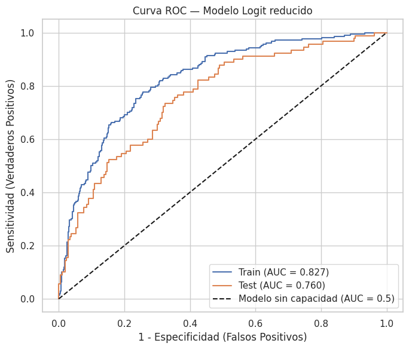

```python
from sklearn.metrics import roc_curve, roc_auc_score

# 1. AUC (área bajo la curva ROC) en train y test
auc_train = roc_auc_score(y_train, y_prob_train)
auc_test  = roc_auc_score(y_test,  y_prob_test)
print(f"AUC train: {auc_train:.3f}")
print(f"AUC test:  {auc_test:.3f}")

# 2. Puntos de la curva ROC (para cada umbral posible)
fpr_train, tpr_train, _ = roc_curve(y_train, y_prob_train)
fpr_test,  tpr_test,  _ = roc_curve(y_test,  y_prob_test)

# 3. Graficar
plt.figure(figsize=(7, 6))
plt.plot(fpr_train, tpr_train, label=f"Train (AUC = {auc_train:.3f})")
plt.plot(fpr_test,  tpr_test,  label=f"Test (AUC = {auc_test:.3f})")
plt.plot([0, 1], [0, 1], "k--", label="Modelo sin capacidad (AUC = 0.5)")
plt.xlabel("1 - Especificidad (Falsos Positivos)")
plt.ylabel("Sensitividad (Verdaderos Positivos)")
plt.title("Curva ROC — Modelo Logit reducido")
plt.legend()
plt.tight_layout()
plt.show()
```

# Evaluación del desempeño del modelo usando la curva ROC y el AUC

El AUC (Área Bajo la Curva ROC) mide la capacidad de un modelo para distinguir correctamente entre dos clases. Cuanto más cercano a 1 sea su valor, mayor será su capacidad de diferenciación.

En este caso, el modelo puede considerarse una buena herramienta de apoyo para la toma de decisiones, ya que permite ordenar a los solicitantes según su nivel de riesgo. Esto puede ayudar al banco a identificar qué créditos podrían aprobarse con mayor facilidad y cuáles requieren un análisis más cuidadoso. Sin embargo, el modelo no debería reemplazar la decisión del analista ni las políticas de crédito de la institución.

Los resultados obtenidos muestran una capacidad de diferenciación razonable entre créditos buenos y malos, con un AUC de 0,827 en train y 0,760 en test. Si bien el desempeño disminuye al aplicarlo sobre datos no utilizados en la estimación, el valor obtenido en test continúa mostrando que el modelo tiene capacidad para diferenciar entre ambas clases. Por lo tanto, resulta útil como herramienta de apoyo, aunque debería complementarse con otra información relevante del cliente.

Como limitación, el AUC proporciona una medida general del desempeño del modelo, pero por sí solo no es suficiente para evaluar su utilidad en la decisión crediticia. No indica qué umbral conviene utilizar para clasificar los créditos ni considera que los distintos errores pueden tener costos diferentes para el banco. En particular, aprobar un crédito malo (falso negativo) puede resultar más costoso que rechazar un crédito bueno (falso positivo).

Además, dos modelos con el mismo AUC pueden comportarse de manera diferente en un aspecto especialmente relevante para el banco: la capacidad de detectar créditos malos. Por este motivo, el AUC debe analizarse junto con otras medidas, como la matriz de confusión, la sensitividad, la especificidad y el análisis de diferentes umbrales de clasificación.

# Umbrales de clasificación

```python
from sklearn.metrics import confusion_matrix

# Probabilidades del modelo reducido
y_prob_train = modelo_reducido_train.predict(X_train_scaled)
y_prob_test  = modelo_reducido_train.predict(X_test_scaled)

umbrales = [0.30, 0.40, 0.50]

def calcular_metricas_por_umbral(y_real, y_prob, umbrales):
    resultados = []
    matrices = {}
    for umbral in umbrales:
        y_pred = (y_prob >= umbral).astype(int)
        tn, fp, fn, tp = confusion_matrix(y_real, y_pred).ravel()
        n = tn + fp + fn + tp
        resultados.append({
            "Umbral": umbral,
            "Precisión": (tp + tn) / n,
            "Tasa de error": (fp + fn) / n,
            "Sensitividad": tp / (tp + fn),
            "Especificidad": tn / (tn + fp),
            "Malos sin detectar (FN)": fn,
            "Buenos rechazados (FP)": fp,
        })
        matrices[umbral] = pd.DataFrame(
            [[tn, fp], [fn, tp]],
            index=["Real 0: bueno", "Real 1: malo"],
            columns=["Predicho 0: bueno", "Predicho 1: malo"]
        )
    return pd.DataFrame(resultados).round(3), matrices

# --- TRAIN ---
tabla_train, matrices_train = calcular_metricas_por_umbral(y_train, y_prob_train, umbrales)
print("Métricas por umbral — TRAIN")
display(tabla_train)

# --- TEST ---
tabla_test, matrices_test = calcular_metricas_por_umbral(y_test, y_prob_test, umbrales)
print("Métricas por umbral — TEST")
display(tabla_test)

# --- Matrices de confusión de TEST, una por umbral ---
for umbral in umbrales:
    print(f"\nMatriz de confusión — TEST — umbral {umbral}")
    display(matrices_test[umbral])
```

```
Métricas por umbral — TRAIN
```

|  | Umbral | Precisión | Tasa de error | Sensitividad | Especificidad | Malos sin detectar (FN) | Buenos rechazados (FP) |
| --- | --- | --- | --- | --- | --- | --- | --- |
| 0 | 0.3 | 0.743 | 0.257 | 0.776 | 0.729 | 47 | 133 |
| 1 | 0.4 | 0.779 | 0.221 | 0.662 | 0.829 | 71 | 84 |
| 2 | 0.5 | 0.780 | 0.220 | 0.495 | 0.902 | 106 | 48 |

```
Métricas por umbral — TEST
```

|  | Umbral | Precisión | Tasa de error | Sensitividad | Especificidad | Malos sin detectar (FN) | Buenos rechazados (FP) |
| --- | --- | --- | --- | --- | --- | --- | --- |
| 0 | 0.3 | 0.687 | 0.313 | 0.689 | 0.686 | 28 | 66 |
| 1 | 0.4 | 0.717 | 0.283 | 0.556 | 0.786 | 40 | 45 |
| 2 | 0.5 | 0.743 | 0.257 | 0.444 | 0.871 | 50 | 27 |

```
Matriz de confusión — TEST — umbral 0.3
```

|  | Predicho 0: bueno | Predicho 1: malo |
| --- | --- | --- |
| Real 0: bueno | 144 | 66 |
| Real 1: malo | 28 | 62 |

```
Matriz de confusión — TEST — umbral 0.4
```

|  | Predicho 0: bueno | Predicho 1: malo |
| --- | --- | --- |
| Real 0: bueno | 165 | 45 |
| Real 1: malo | 40 | 50 |

```
Matriz de confusión — TEST — umbral 0.5
```

|  | Predicho 0: bueno | Predicho 1: malo |
| --- | --- | --- |
| Real 0: bueno | 183 | 27 |
| Real 1: malo | 50 | 40 |

# Análisis para diferentes umbrales de clasificación

En caso de que el banco quiera reducir la cantidad de créditos malos no detectados conviene bajar el umbral, porque de esta forma el modelo identifica una mayor cantidad de créditos malos.

Es decir, el banco reduce el riesgo de otorgar créditos malos, pero a cambio rechaza más clientes que en realidad eran buenos.

Por lo tanto, bajar el umbral reduce el riesgo crediticio porque permite detectar más créditos malos, pero aumenta el rechazo de clientes que en realidad son buenos. Subirlo tendría el efecto contrario: se aprobarían más buenos clientes, pero también aumentaría el riesgo de no detectar créditos malos. En este caso, un umbral de 0,4 podría ser una alternativa razonable si el banco quiere priorizar un poco más la detección del riesgo sin aumentar demasiado los rechazos incorrectos. La decisión final debería depender del costo económico que tenga para el banco otorgar un crédito malo frente al costo de rechazar un cliente bueno.

# Decisión financiera

```
Costo esperado por umbral — TRAIN
```

|  | Umbral | FN (malos sin detectar) | FP (buenos rechazados) | Costo total |
| --- | --- | --- | --- | --- |
| 0 | 0.05 | 4 | 404 | 424 |
| 1 | 0.10 | 9 | 306 | 351 |
| 2 | 0.15 | 16 | 245 | 325 |
| 3 | 0.20 | 29 | 194 | 339 |
| 4 | 0.25 | 36 | 158 | 338 |
| 5 | 0.30 | 47 | 133 | 368 |
| 6 | 0.35 | 62 | 108 | 418 |
| 7 | 0.40 | 71 | 84 | 439 |
| 8 | 0.45 | 83 | 71 | 486 |
| 9 | 0.50 | 106 | 48 | 578 |
| 10 | 0.55 | 119 | 39 | 634 |
| 11 | 0.60 | 133 | 26 | 691 |
| 12 | 0.65 | 148 | 16 | 756 |
| 13 | 0.70 | 166 | 12 | 842 |
| 14 | 0.75 | 178 | 10 | 900 |
| 15 | 0.80 | 189 | 5 | 950 |
| 16 | 0.85 | 197 | 3 | 988 |
| 17 | 0.90 | 204 | 3 | 1023 |

```
Costo esperado por umbral — TEST
```

|  | Umbral | FN (malos sin detectar) | FP (buenos rechazados) | Costo total |
| --- | --- | --- | --- | --- |
| 0 | 0.05 | 3 | 171 | 186 |
| 1 | 0.10 | 7 | 140 | 175 |
| 2 | 0.15 | 9 | 116 | 161 |
| 3 | 0.20 | 16 | 96 | 176 |
| 4 | 0.25 | 21 | 79 | 184 |
| 5 | 0.30 | 28 | 66 | 206 |
| 6 | 0.35 | 38 | 54 | 244 |
| 7 | 0.40 | 40 | 45 | 245 |
| 8 | 0.45 | 43 | 36 | 251 |
| 9 | 0.50 | 50 | 27 | 277 |
| 10 | 0.55 | 53 | 22 | 287 |
| 11 | 0.60 | 61 | 14 | 319 |
| 12 | 0.65 | 68 | 10 | 350 |
| 13 | 0.70 | 71 | 6 | 361 |
| 14 | 0.75 | 78 | 4 | 394 |
| 15 | 0.80 | 82 | 2 | 412 |
| 16 | 0.85 | 82 | 1 | 411 |
| 17 | 0.90 | 84 | 1 | 421 |

```
Umbral óptimo según costo esperado (TRAIN): 0.15
Umbral óptimo según costo esperado (TEST): 0.15
```

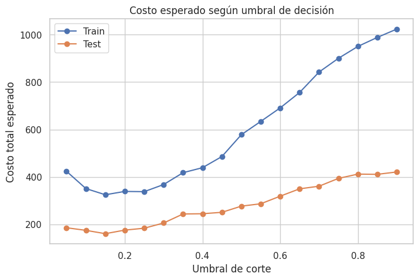

```python
import numpy as np
import matplotlib.pyplot as plt

# Costos relativos de cada tipo de error
# (el número exacto es una decisión de negocio; acá usamos 5 a modo de ejemplo)
costo_fn = 5   # costo de dejar pasar un crédito malo (falso negativo)
costo_fp = 1   # costo de rechazar un cliente bueno (falso positivo)

umbrales_costo = np.arange(0.05, 0.95, 0.05)

def costo_esperado_por_umbral(y_real, y_prob, umbrales, costo_fn, costo_fp):
    resultados = []
    for umbral in umbrales:
        y_pred = (y_prob >= umbral).astype(int)
        tn, fp, fn, tp = confusion_matrix(y_real, y_pred).ravel()
        costo_total = fn * costo_fn + fp * costo_fp
        resultados.append({
            "Umbral": round(umbral, 2),
            "FN (malos sin detectar)": fn,
            "FP (buenos rechazados)": fp,
            "Costo total": costo_total
        })
    return pd.DataFrame(resultados)

tabla_costos_train = costo_esperado_por_umbral(y_train, y_prob_train, umbrales_costo, costo_fn, costo_fp)
tabla_costos_test = costo_esperado_por_umbral(y_test, y_prob_test, umbrales_costo, costo_fn, costo_fp)

print("Costo esperado por umbral — TRAIN")
display(tabla_costos_train)

print("Costo esperado por umbral — TEST")
display(tabla_costos_test)

# Umbral que minimiza el costo total
umbral_optimo_train = tabla_costos_train.loc[tabla_costos_train["Costo total"].idxmin(), "Umbral"]
umbral_optimo_test = tabla_costos_test.loc[tabla_costos_test["Costo total"].idxmin(), "Umbral"]

print(f"\nUmbral óptimo según costo esperado (TRAIN): {umbral_optimo_train}")
print(f"Umbral óptimo según costo esperado (TEST): {umbral_optimo_test}")

# Gráfico
plt.figure(figsize=(8,5))
plt.plot(tabla_costos_train["Umbral"], tabla_costos_train["Costo total"], marker="o", label="Train")
plt.plot(tabla_costos_test["Umbral"], tabla_costos_test["Costo total"], marker="o", label="Test")
plt.xlabel("Umbral de corte")
plt.ylabel("Costo total esperado")
plt.title("Costo esperado según umbral de decisión")
plt.legend()
plt.grid(True)
plt.show()
```

```python
# 1. Armamos una tabla con la probabilidad estimada de cada crédito del test
resultados = pd.DataFrame({
    "prob_credito_malo_estimada": y_prob_test,
    "real": y_test.values
})

# 2. Regla de decisión de tres tramos (cortes propios, justificados)
def regla_decision(prob):
    if prob < 0.15:
        return "Aprobar"
    elif prob < 0.40:
       return "Revisión manual"
    else:
        return "Rechazar o exigir garantías"

# 3. Aplicamos la regla a cada crédito
resultados["decision_sugerida"] = resultados["prob_credito_malo_estimada"].apply(regla_decision)

# 4. Vemos las primeras filas y el reparto de decisiones
display(resultados.head(10))
print("\nCantidad de casos por decisión sugerida:")
print(resultados["decision_sugerida"].value_counts())
```

|  | prob_credito_malo_estimada | real | decision_sugerida |
| --- | --- | --- | --- |
| 90 | 0.304556 | 0.0 | Revisión manual |
| 259 | 0.063110 | 0.0 | Aprobar |
| 247 | 0.140080 | 0.0 | Aprobar |
| 730 | 0.657497 | 0.0 | Rechazar o exigir garantías |
| 432 | 0.208000 | 0.0 | Revisión manual |
| 194 | 0.057804 | 0.0 | Aprobar |
| 41 | 0.431782 | 0.0 | Rechazar o exigir garantías |
| 339 | 0.003513 | 0.0 | Aprobar |
| 254 | 0.017718 | 0.0 | Aprobar |
| 906 | 0.740960 | 1.0 | Rechazar o exigir garantías |

```
Cantidad de casos por decisión sugerida:
decision_sugerida
Aprobar                        103
Revisión manual                102
Rechazar o exigir garantías     95
Name: count, dtype: int64
```

```python
# Cantidad de casos por decisión sugerida
resultados["decision_sugerida"].value_counts()
```

| decision_sugerida | count |
| --- | --- |
| Aprobar | 103 |
| Revisión manual | 102 |
| Rechazar o exigir garantías | 95 |

**dtype:** int64

# Regla de decisión propuesta y su justificación financiera

[output not shown]

Regla de decisión propuesta

Se estiman los umbrales apoyando nuestra decisión en un supuesto de costos: asumimos que otorgar un crédito que termina siendo malo le cuesta al banco aproximadamente 5 veces más que la ganancia que le habría dejado un crédito bueno. En otras palabras, la pérdida de un crédito malo mal aprobado equivale a la ganancia que hubieran generado 5 créditos buenos no abrobados.

Bajo este supuesto, calculamos el costo total esperado (FN × 5 + FP × 1) para distintos umbrales de corte entre 0.05 y 0.90. El resultado muestra que el costo mínimo se alcanza en la zona de 0.15, muy por debajo del umbral por defecto de 0.50, lo cual tiene sentido financiero: si un error de tipo "dejar pasar un crédito malo" es mucho más caro, conviene ser más exigente a la hora de aprobar.

A partir de este resultado, proponemos la siguiente regla de decisión en tres tramos:

Probabilidad estimada < 0.15 → Aprobar directamente. Es la zona donde el costo esperado es mínimo; el riesgo de default es lo suficientemente bajo como para aprobar.

Probabilidad estimada entre 0.15 y 0.40 → Revisión manual. Es una zona intermedia de incertidumbre: el modelo no está lo bastante seguro en ninguna dirección, por lo que conviene que un analista evalúe el caso con información adicional antes de decidir.

Probabilidad estimada ≥ 0.40 → Rechazar o exigir garantías adicionales. A partir de este punto, el riesgo estimado es demasiado alto para aprobar el crédito en las condiciones estándar; se opta por exigir garantías extra o rechazar directamente la operación.

Esta regla no es simétrica a propósito: refleja que, para el banco, es mucho más costoso aprobar un mal crédito que rechazar uno bueno, por lo que el modelo se comporta de manera deliberadamente conservadora.

Como información adicional a los clientes que superen el umbral del 0.15 se podría solicitar datos que el modelo no incluye y que reducen la incertidumbre, especialmente en la zona de revisión manual: ingresos actualizados y comprobables, nivel de endeudamiento en otras entidades (informe de central de riesgos), estabilidad, patrimonio y antigüedad laboral, y el destino real del crédito. También podría considerarse el historial interno del cliente si ya es cliente del banco.

# Conclusión ejecutiva

Podemos concluir que el modelo Logit desarrollado tiene una capacidad razonable para explicar y diferenciar el riesgo de crédito, aunque no permite identificar todos los casos. El modelo reducido conserva buena parte de la capacidad explicativa utilizando menos variables. Esto permite trabajar con un modelo más simple y fácil de interpretar, manteniendo resultados adecuados para el objetivo planteado.

Al analizar la matriz de confusión, se observa una diferencia importante entre la capacidad para identificar créditos buenos y malos. En la muestra de test, con un umbral de 0,5, el modelo clasifica correctamente 183 de los 210 créditos buenos, y 40 de los 90 créditos malos. Por lo tanto, el modelo tiene una mayor capacidad para reconocer buenos clientes de aquellos que no lo son.

Esto también se refleja en la especificidad de 0,871, que indica que el modelo identifica correctamente aproximadamente el 87% de los créditos buenos, mientras que la sensitividad de 0,444 muestra que detecta aproximadamente el 44% de los créditos malos. Por lo tanto, con un umbral de 0,5 quedan 50 créditos malos sin detectar, lo que representa una limitación importante desde el punto de vista financiero, ya que estos clientes podrían recibir un crédito a pesar de presentar un mayor riesgo de incumplimiento.

Sin embargo, el desempeño general del modelo es razonable. La precisión alcanza 0,780 en train y 0,743 en test, mientras que el AUC es de 0,827 y 0,760, respectivamente. Las diferencias entre las muestras de entrenamiento y prueba no son demasiado grandes, lo que indica que el modelo mantiene un comportamiento relativamente estable cuando se enfrenta a datos que no utilizó para su estimación.

El análisis de los distintos umbrales muestra además que la clasificación puede adaptarse según los objetivos del banco. Al disminuir el umbral aumenta la capacidad para detectar créditos malos, pero también aumenta la cantidad de buenos clientes rechazados. Por este motivo, la elección del umbral debería considerar el costo de ambos tipos de errores y la política de riesgo que quiera adoptar la institución.

En resumen, consideramos que el modelo puede ser útil como herramienta de apoyo para una decisión crediticia, principalmente para ordenar a los solicitantes según su nivel de riesgo e identificar aquellos casos que requieren mayor análisis. Sin embargo, sus resultados no justifican utilizarlo como único criterio para aprobar o rechazar un crédito. La matriz de confusión muestra que todavía existe una cantidad relevante de créditos malos que el modelo no logra detectar, por lo que la decisión debería complementarse con información adicional del solicitante y con el análisis de un especialista.

Declaración sobre el uso de inteligencia artificial

Para la realización de este trabajo se utilizaron herramientas de inteligencia artificial (Claude, ChatGPT) como apoyo en las siguientes tareas: comprensión de conceptos econométricos, revisión y depuración de código en Python, sugerencias de redacción.

El uso de estas herramientas fue de carácter complementario. Las decisiones metodológicas, la selección y justificación del modelo, el análisis de los datos y la interpretación final de los resultados fueron elaborados y revisados por los integrantes del grupo.